# Exploring and Modeling the Continuous Corn Yield Penalty

5/20/2020

## Motivation

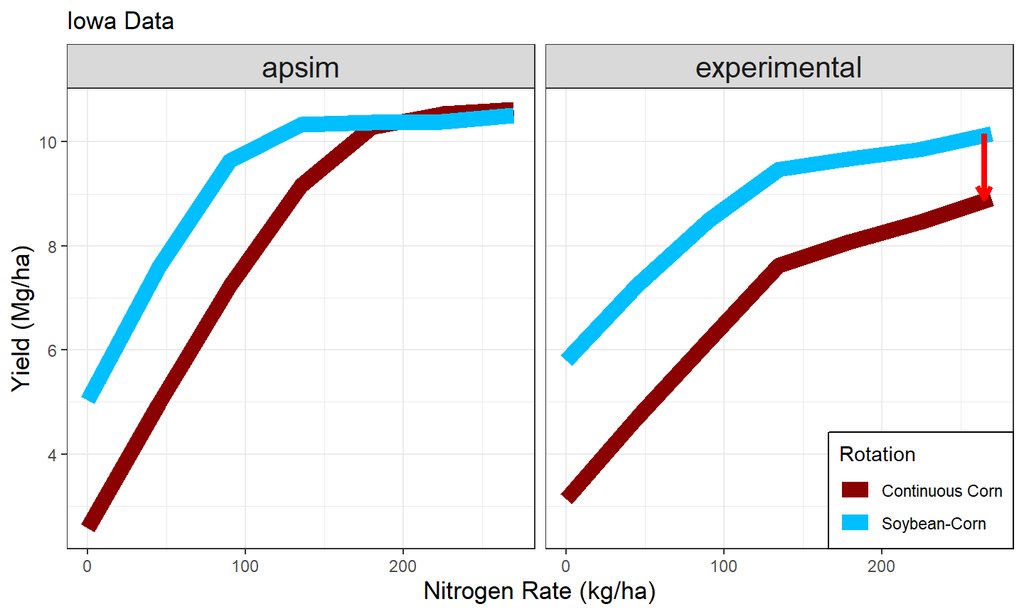

## Continuous Corn Yields Relative to Rotated Corn Yields

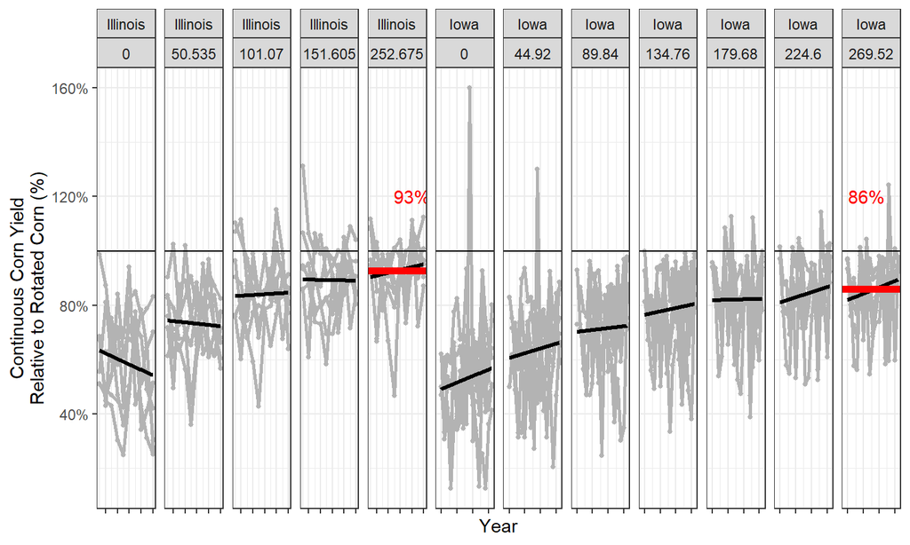

## Gap at highest N-rate, absolute values

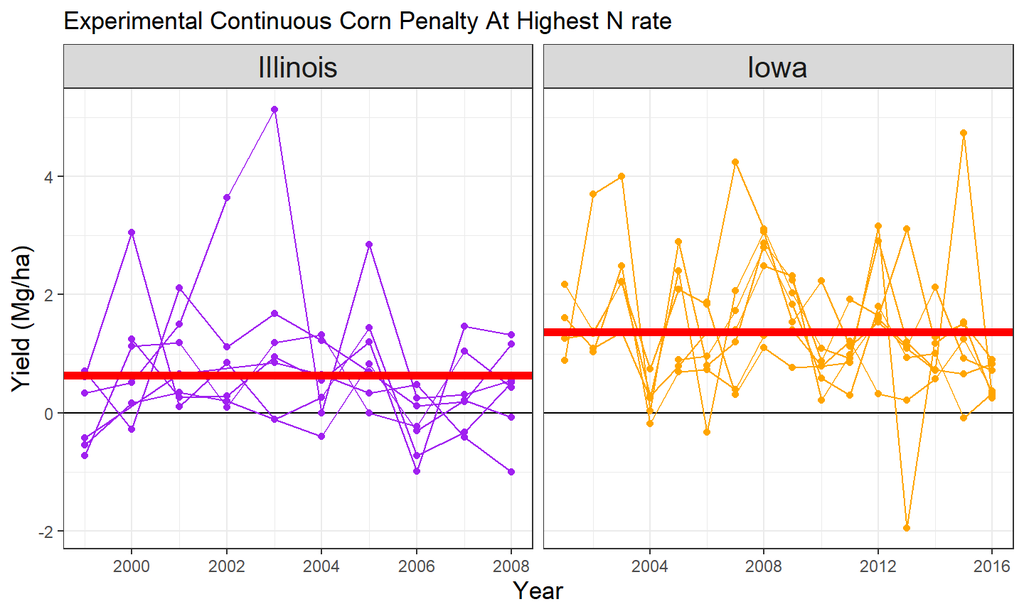

## Previous work

Nothing has been done on a mid-level scale

- Limited to one or two sites (5 studies), or uses satellite data (1 study)
- Statistical models from one site (ex. Gentry et al. 2013) do not work in Iowa (we tried)
- Explore limited explanatory variables

## Hypotheses and Objectives

**Objectives:**

- Use statistical models and experimental data to find environments associated with higher contin. corn penalties
- Use literature to identify physical manifestations of cont. corn penalty
- Use results to incorporate cont. corn yield penalty into APSIM algorithms

## Hypotheses and Objectives Cont.

**Hypotheses:**

\(H_1\) The continuous corn penalty is not random and can be captured and described by a process-based model.

\(H_0\) The penalty is related to biotic phenomena (disease) that cannot be captured by a process-based model that only captures abiotic processes.

## Preliminary Approach, Iowa

- Gather variables
- Identify variables with sufficient variation
- Assess colinearity, eliminate highly correlated variables

## Resulting Iowa-based variables

Management-based

Management Variables Included In Models

[output not shown]

## Resulting Iowa-based variables

Weather-based

Weather Variables Included In Models

| Variable | units | mean | min | max |
| --- | --- | --- | --- | --- |
| # Days w/Tmax > 30oC from planting to 120 DAP (WEA) | days | 28 | 5 | 70 |
| # Days after planting to acheive 140 GDDs (WEA) | days | 24 | 10 | 40 |
| Total Precip 2 weeks after planting (WEA) | mm | 54 | 0 | 252 |
| Total Precip 2 weeks before planting (WEA) | mm | 42 | 0 | 113 |
| Mean low temp 4 weeks around planting (WEA) | degC | 7 | 1 | 14 |
| # of days < 4degF Jan 1 - planting (WEA) | days | 19 | 3 | 50 |
| GDDs 0-2mo after planting (WEA) | 10degC base, 30degC max | 517 | 246 | 797 |

## Resulting Iowa-based variables

Soil-based

Soil Variables Included In Models

| Variable | units | mean | min | max |
| --- | --- | --- | --- | --- |
| Depth to Water Table (SSURGO) | cm | 142 | 120 | 230 |
| Iowa Corn Suitability Rating (SSURGO) | unitless | 87 | 74 | 97 |
| Depth to B horizon (SSURGO) | cm | 33 | 28 | 37 |
| 0-60cm % clay (SSURGO) | % | 20 | 18 | 22 |
| 0-30cm % organic carbon (SSURGO) | % | 2 | 1 | 2 |
| 0-150cm plant-available-water (SSURGO) | mm | 268 | 225 | 310 |

## What environments are associated with higher yield gaps in Iowa?

- Random forest models to identify important variables to include in regression analysis
- LASSO regression to quantify magnitude and direction of important associations

## Random forest model results

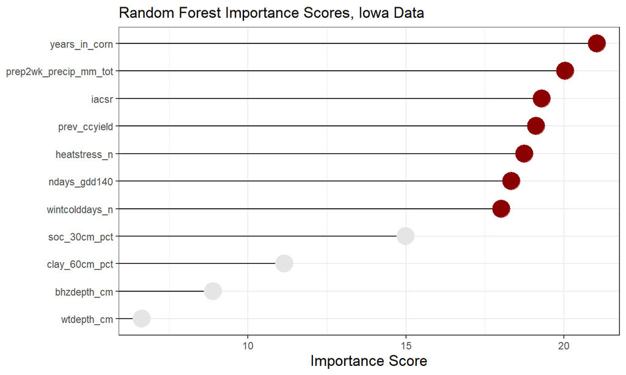

## LASSO regression results

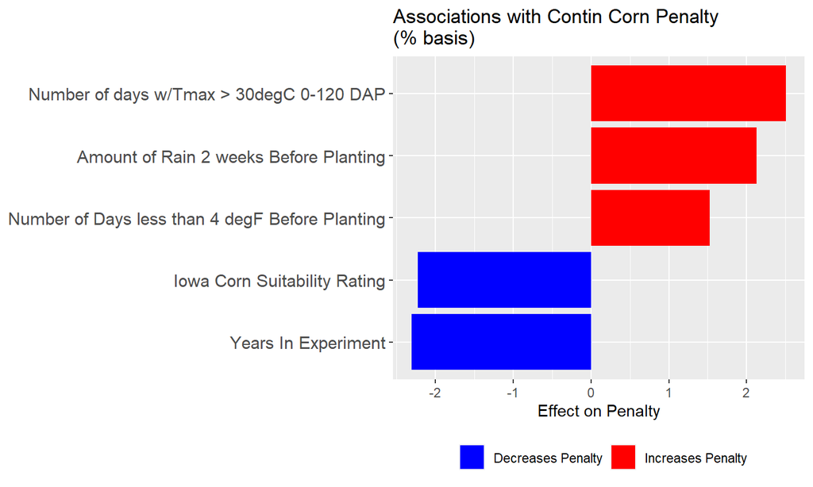

## Does the penalty increase over time?

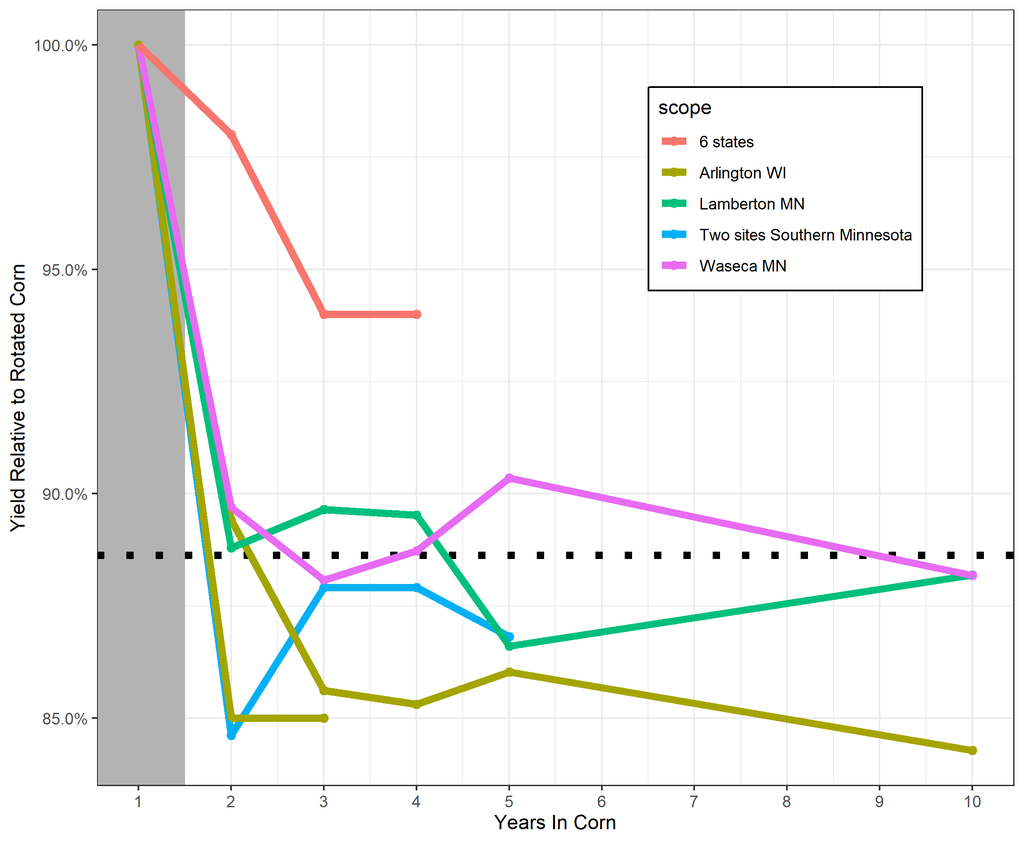

## Summary of preliminary results (Iowa-based)

*Summary:*

## Possible targets in APSIM?

Don’t worry about the acronyms, the point is the magnitude

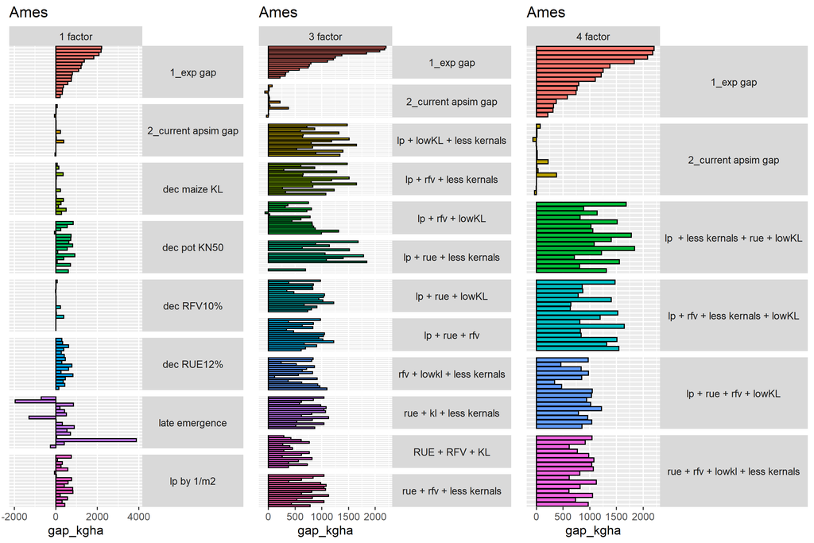

## APSIM targets

*Summary:*

- There are parameters that can be changed that, in combination, re-create the magnitude of the cont. corn penalty
- Creating an algorithm that adjusts these parameters based on soil/weather/management has the potential to capture the patterns

## Next steps

*Next:*

- Include IL data in random forest variable selection and LASSO regression
- Re-evaluate implementation of APSIM adjustments
- Implement select changes in APSIM, assess how model performs

## Iowa and Illinois Yields Over Time

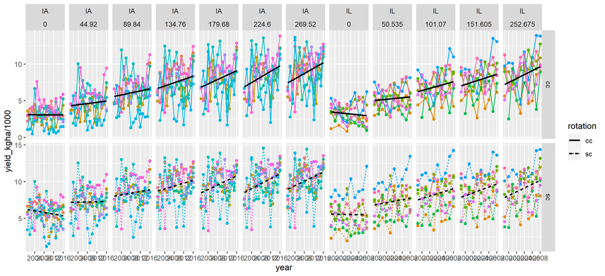